# LendingClubAnalysis

Steve Isaacs, Kailing See, Sally Guo, Cristian Benavides, Olivier Boulant

1/12/2017

Business Problem: Assessing credit worthiness of customers in Lending Club and their probability of defaulting.

Data set: https://www.kaggle.com/wendykan/lending-club-loan-data

### 1.Introduction to the Business Problem

Lending Club is the world’s largest online marketplace connecting borrowers and investors. They operate at a lower cost than traditional bank lending programs and pass the savings on to borrowers in the form of lower rates and to investors in the form of solid returns. Source: https://www.lendingclub.com/

This project aims to analyse Lending Club’s issued loans over a 9 year period (2007-2015) and identify early indicators that could predict a customer’s probability of defaulting. The insights obtained could help Lending Club to: a) Develop customer profiles with High vs Low Default Risk b) Design differentiated credit approval processes for different customer segments (e.g faster approval time, minimal security for low risk customers)

The outcome of the above actions has the potential to shape Lending Club’s product offering, attract the right kind of borrowers and provide investors with stronger returns, thereby improving its own business performance.

### 2.Process to solve the Business Problem

For the purpose of this analysis, we will follow the below process:  
1. Understand Lending Club’s Business Model & Data Set  
2. Generate hypothesis on which borrower characteritics contribute to probability of default  
3. Idenfity relevant attributes from dataset  
4. Clean the selected data to remove any NA & outliers  
5. Test correlation of selected data to understand their relative dependency  
6. Split dataset into 80% estimation (training) , 10% validation and 10% testing  
7. Apply classification tree method on testing dataset and check against validation dataset (iterate if required)  
8. Summarise implication on Lending Club business decisions based on classification tree’s output

### 3.Generate hypothesis on which borrower characteritics contribute to probability of default

There are 74 fields (columns) in Lending Club’s dataset with many fields capturing irrelevant data or duplicative data measuring similar information. An example of irrelevant data would be “URL” of customer’s profile. An example of data measuring similar information would be “Loan Grade” & “SubGrade” where “Loan Grade” rates the quality of the Loan & “SubGrade” is a more granular level of Loan Grade.

The team applied judgement based on both our understanding of Lending Club’s business and our goal within this analysis, in order to identify 11 key fields that are particularly relevant for this analysis:

“ID”: Unique identification number tagged to the loan “LoanStatus”: Whether the loan in question has been Charged Off (1=Delinquent), Fully Paid (0), Current (0 =still outstanding) “LoanAmount”: Amount of loan issued “LoanTerm”: Duration of loan, either 36 months or 60 months “AnnualIncome”: Annual income of the borrower “EmploymentLength”: Employment length in years. Possible values are between 0 and 10 where 0 means less than one year and 10 means ten or more years. “PublicRecords”: Number of derogatory public records “NumberCreditLines”: The number of open credit lines in the borrower’s credit file “DelinquencyPrior2Years”: The number of 30+ days past-due incidences of delinquency in the borrower’s credit file for the past 2 years “LoanGrade”: Lending Club’s assigned loan grade “InterestRate”: Annual Interest Rate on the loan

### 4. Treatment of Dataset (Convert to Metric, Cleanse & Scale) (Step 4 - 5)

Imported data from these 11 fields are then treated by converting them to be metric and numeric from descriptive/categorical. For example, Employment Length, which was of the form “9 years” in the raw data was subsequently converted to “9”.

Conversion is applied to the fields “LoanStatus”, “EmploymentLength” & “LoanGrade”. For “LoanGrade”, we have assumed that Grade A is better than B which is better than C, and that A, B, C differ by the same extent and therefore can be replaced by metric 1, 2, 3.

Data is also: a) cleansed to remove any “NA” fields using ‘na.omit’ b) normalised for fields “LoanAmount”, “LoanTerm”, “Annual Income”, “EmploymentLength”, “NumberofCreditLines”, “DelinquencyPiror2Years”, “LoanGrade”, “InterestRate” with mean 0 and standard deviation 1.

For LoanGrade, there could be 2 possible interpretation of the factors “A-G”. First interpretation is that these factors are catergorical (i.e they represent group of similar qualitative attributes such as “High Net Worth”, “Bankrupt Borrowers”). The 2nd interpretation is that these factors are scaled (i.e “A” is better than “B” is better than “C”) and are measured based on linear numerical attributes such as ‘Interest Coverage Ratio’.

### 5.Split Dataset into Estimation, Validation and Test Data (Step 6)

In this section, we set the dependent variable as Loan Status witha Binary Output of 1 if Delinquiet, 0 otherwise Independent variables would be the remaining 9 attributes (i.e all others except ID)

We also define the proportion of Estimation Data as 80% of the ProjectDataScaled (Treated Dataset from #4), Validation Data as 10% and Test Data as 10%.

Finally we randomly sampled the ProjectDataScaled to obtain the 3 sets of data as mentioned above.

|  | Class 1 | Class 0 |
| --- | --- | --- |
| # of Observations | 40270 | 609138 |

|  | Class 1 | Class 0 |
| --- | --- | --- |
| # of Observations | 668 | 80508 |

```r
#knitr::kable(round(my_summary(estimation_data[estimation_data[,dependent_variable]==1,independent_variables]),2))
```

```r
#knitr::kable(round(my_summary(estimation_data[estimation_data[,dependent_variable]==0,independent_variables]),2))
```

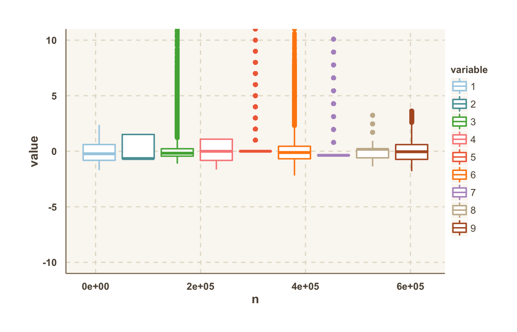

```r
DVvalues = unique(estimation_data[,dependent_variable])
x0 = estimation_data[which(estimation_data[,dependent_variable]==DVvalues[1]),independent_variables]
x1 = estimation_data[which(estimation_data[,dependent_variable]==DVvalues[2]),independent_variables]
colnames(x0) <- 1:ncol(x0)
colnames(x1) <- 1:ncol(x1)

# OBoulant : had to add the following line :
ggthemr::ggthemr('dust')
swatch.default <- as.character(ggthemr::swatch())
ggthemr::set_swatch(c(swatch.default[1], colorRampPalette(RColorBrewer::brewer.pal(12, "Paired"))(ncol(x0))))
ggplot2::ggplot(reshape2::melt(cbind.data.frame(n=1:nrow(x0), x0), id="n"), ggplot2::aes(x=n, y=value, colour=variable)) + ggplot2::geom_boxplot(fill="#FFFFFF", size=0.66, position=ggplot2::position_dodge(1.1*nrow(x0))) + ggplot2::coord_cartesian(ylim=c(-10,10)) # OBoulant : i added the y axis limits
```

```r
ggthemr::set_swatch(swatch.default)
```

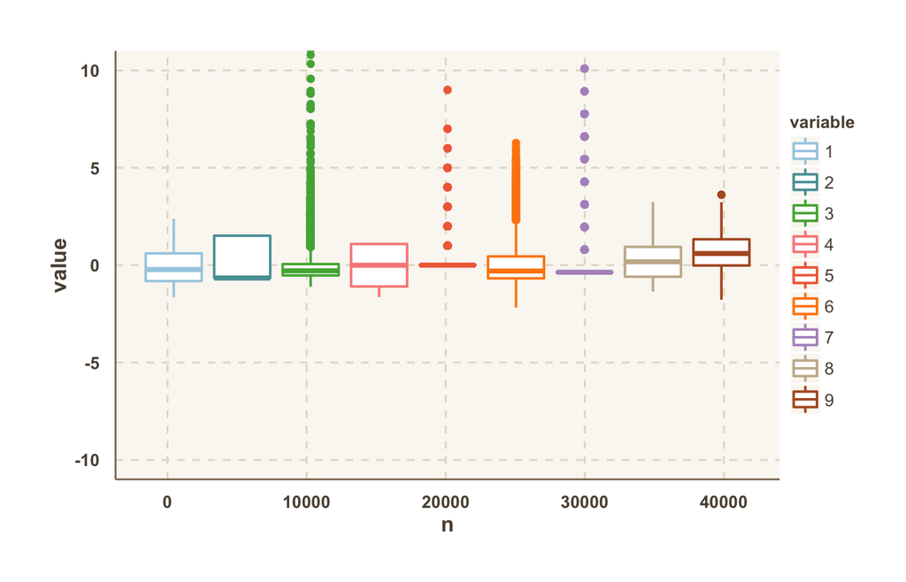

```r
swatch.default <- as.character(ggthemr::swatch())
ggthemr::set_swatch(c(swatch.default[1], colorRampPalette(RColorBrewer::brewer.pal(12, "Paired"))(ncol(x1))))
ggplot2::ggplot(reshape2::melt(cbind.data.frame(n=1:nrow(x1), x1), id="n"), ggplot2::aes(x=n, y=value, colour=variable)) + ggplot2::geom_boxplot(fill="#FFFFFF", size=0.66, position=ggplot2::position_dodge(1.1*nrow(x1))) + ggplot2::coord_cartesian(ylim=c(-10,10)) # OBoulant : i added the y axis limits
```

```r
ggthemr::set_swatch(swatch.default)
```

### 6. Apply Classification Tree method on Estimation Dataset and check against Validation dataset (Iterate if required) (Step 7)

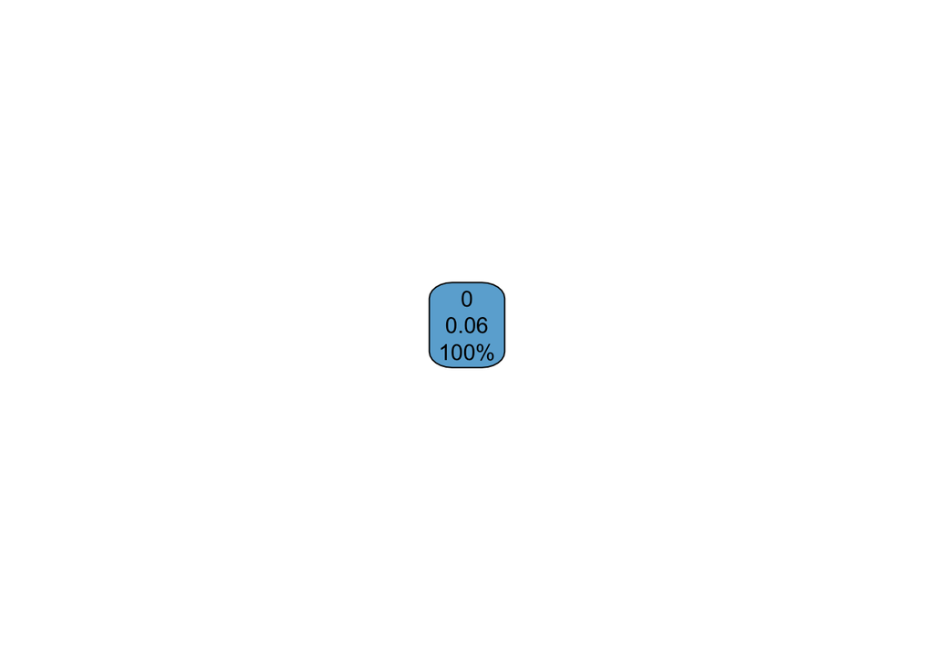

```r
# just name the variables numerically so that they look ok on the tree plots
independent_variables_nolabel = paste("IV", 1:length(independent_variables), sep="")

estimation_data_nolabel = cbind(estimation_data[,dependent_variable], estimation_data[,independent_variables])
colnames(estimation_data_nolabel)<- c(colnames(estimation_data)[dependent_variable],independent_variables_nolabel)

validation_data_nolabel = cbind(validation_data[,dependent_variable], validation_data[,independent_variables])
colnames(validation_data_nolabel)<- c(dependent_variable,independent_variables_nolabel)

test_data_nolabel = cbind(test_data[,dependent_variable], test_data[,independent_variables])
colnames(test_data_nolabel)<- c(dependent_variable,independent_variables_nolabel)

estimation_data_nolabel = data.frame(estimation_data_nolabel)
validation_data_nolabel = data.frame(validation_data_nolabel)
test_data_nolabel = data.frame(test_data_nolabel)

estimation_data = data.frame(estimation_data)
validation_data = data.frame(validation_data)
test_data = data.frame(test_data)

formula=paste(colnames(estimation_data)[dependent_variable],paste(Reduce(paste,sapply(head(independent_variables_nolabel,-1), function(i) paste(i,"+",sep=""))),tail(independent_variables_nolabel,1),sep=""),sep="~")
CART_tree<-rpart::rpart(formula, data=estimation_data_nolabel, method="class", control=CART_control)
rpart.plot::rpart.plot(CART_tree)
```

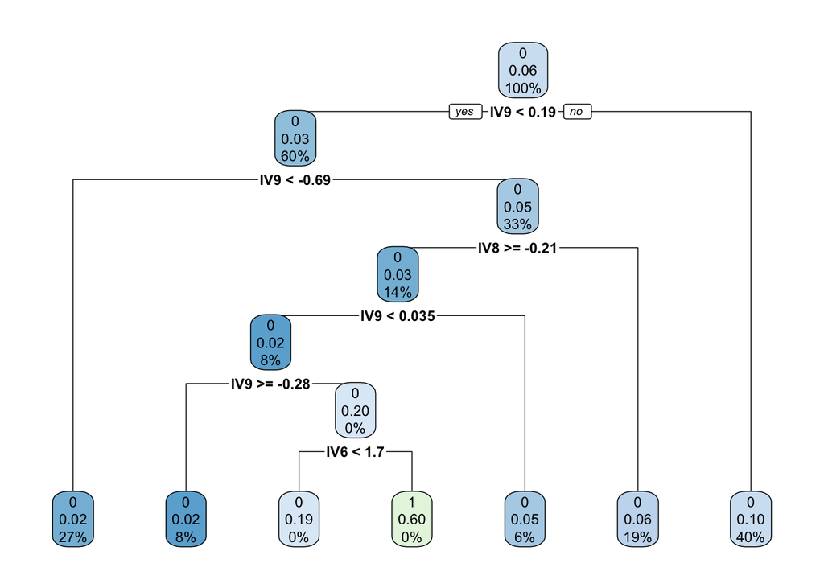

```r
CART_tree_large<-rpart::rpart(formula, data=estimation_data_nolabel, method="class", control=rpart::rpart.control(cp=0.000001, maxdepth=6, minbucket = 2))
rpart.plot::rpart.plot(CART_tree_large)
```

### 7.Summarise implication on Lending Club Business Decisions based on Classification Tree’s output

The Classification Tree applied based on Estimation Data shows that: a) Customers with an interest rate greater than 14.02% (13.19+0.19x4.37 = 14.0203) are approximately 3 times as likely to default as those with an interest rate below 14.02%. b) For customers with a lower interest rate (between 10.17% and 11.97%), a loan grade of greater than 2.5 (i.e. C, D, E, etc), and more than 20.65 credit lines default very often (60% of the time).

```r
# Let's first calculate all probabilites for the estimation, validation, and test data
# estimation_Probability_class1_tree<-predict(CART_tree, estimation_data_nolabel)[,2]
# estimation_Probability_class1_tree_large<-predict(CART_tree_large, estimation_data_nolabel)[,2]
#
# validation_Probability_class1_tree<-predict(CART_tree, validation_data_nolabel)[,2]
# validation_Probability_class1_tree_large<-predict(CART_tree_large, validation_data_nolabel)[,2]
#
# test_Probability_class1_tree<-predict(CART_tree, test_data_nolabel)[,2]
# test_Probability_class1_tree_large<-predict(CART_tree_large, test_data_nolabel)[,2]
#
# estimation_prediction_class_tree=1*as.vector(estimation_Probability_class1_tree > Probability_Threshold)
# estimation_prediction_class_tree_large=1*as.vector(estimation_Probability_class1_tree_large > Probability_Threshold)
#
# validation_prediction_class_tree=1*as.vector(validation_Probability_class1_tree > Probability_Threshold)
# validation_prediction_class_tree_large=1*as.vector(validation_Probability_class1_tree_large > Probability_Threshold)
#
# test_prediction_class_tree=1*as.vector(test_Probability_class1_tree > Probability_Threshold)
# test_prediction_class_tree_large=1*as.vector(test_Probability_class1_tree_large > Probability_Threshold)
#
# Classification_Table=rbind(validation_data[,dependent_variable],validation_Probability_class1_tree)
# rownames(Classification_Table)<-c("Actual Class","Probability of Class 1")
# colnames(Classification_Table)<- paste("Obs", 1:ncol(Classification_Table), sep=" ")
#
# Classification_Table_large=rbind(validation_data[,dependent_variable],validation_Probability_class1_tree)
# rownames(Classification_Table_large)<-c("Actual Class","Probability of Class 1")
# colnames(Classification_Table_large)<- paste("Obs", 1:ncol(Classification_Table_large), sep=" ")
#
# show_data = data.frame(round(Classification_Table,2))
# show_data = show_data[,1:min(max_data_report,ncol(show_data))]
# row<-rownames(show_data)
# dfnew<-cbind(row,show_data)
# change<-colnames(dfnew)
# change[1]<-"Classification Table"
# colnames (dfnew)<-change
# m1<-googleVis::gvisTable(dfnew,options=list(showRowNumber=TRUE,width=1220, height=140,allowHTML=TRUE,page='disable'))
# print(m1,'chart')
#
# knitr::kable(head(t(round(Classification_Table,2)), max_data_report))
```

```r
# formula_log=paste(colnames(estimation_data[,dependent_variable,drop=F]),paste(Reduce(paste,sapply(head(independent_variables,-1), function(i) paste(colnames(estimation_data)[i],"+",sep=""))),colnames(estimation_data)[tail(independent_variables,1)],sep=""),sep="~")
#
# logreg_solution <- glm(formula_log, family=binomial(link="logit"),  data=estimation_data)
#
# log_coefficients = round(summary(logreg_solution)$coefficients,1)
# print(xtable::xtable(log_coefficients,caption="Logistic Regression: Estimated Coefficients" , digits=1,),type="html",html.table.attributes = "class='table table-striped table-hover table-bordered'",caption.placement="top",comment = FALSE,include.rownames = TRUE)
#
# knitr::kable(round(log_coefficients,2))
```

```r
# Let's get the probabilities for the 3 types of data again
# estimation_Probability_class1_log<-predict(logreg_solution, type="response", newdata=estimation_data[,independent_variables])
# validation_Probability_class1_log<-predict(logreg_solution, type="response", newdata=validation_data[,independent_variables])
# test_Probability_class1_log<-predict(logreg_solution, type="response", newdata=test_data[,independent_variables])
#
# estimation_prediction_class_log=1*as.vector(estimation_Probability_class1_log > Probability_Threshold)
# validation_prediction_class_log=1*as.vector(validation_Probability_class1_log > Probability_Threshold)
# test_prediction_class_log=1*as.vector(test_Probability_class1_log > Probability_Threshold)
#
# Classification_Table=rbind(validation_data[,dependent_variable],validation_Probability_class1_log)
# rownames(Classification_Table)<-c("Actual Class","Probability of Class 1")
# colnames(Classification_Table)<- paste("Obs", 1:ncol(Classification_Table), sep=" ")
#
# show_data = data.frame(round(Classification_Table,2))
# show_data = show_data[,1:min(max_data_report,ncol(show_data))]
# row<-rownames(show_data)
# dfnew<-cbind(row,show_data)
# change<-colnames(dfnew)
# change[1]<-"Classification Table"
# colnames (dfnew)<-change
# m1<-googleVis::gvisTable(dfnew,options=list(showRowNumber=TRUE,width=1220, height=140,allowHTML=TRUE,page='disable'))
# print(m1,'chart')
#
# knitr::kable(head(t(round(Classification_Table,2)), max_data_report))
```